# 1.0 Read importing

# Importing RNA-seq reads

```r
# BiocManager::install("tximport")
library(tximport)
library(tidyverse)
selectGenes <- function(counts, min.count=2){
  keep <-
    counts[rowMeans(counts)>min.count, ]
  return(keep)
}
```

# Load age data

Then, read the gene age data for all species under study. Gene ages were chosen based on the isoform with the oldest age profile.

```r
Ec_age <- readr::read_tsv("data/2880_gene_ages.tsv") %>% dplyr::rename(GeneID = `#gene`)
Fd_age <- readr::read_tsv("data/Fd_age_complete.tsv") %>%
  dplyr::mutate(GeneID = str_remove(GeneID, '\\.p[0-9].*')) %>%
  dplyr::group_by(GeneID) %>%
  dplyr::slice(which.min(rank)) %>%
  dplyr::ungroup()
Fs_age <- readr::read_tsv("data/Fs_age_complete.tsv") %>%
  dplyr::mutate(GeneID = str_remove(GeneID, '\\.p[0-9].*')) %>%
  dplyr::group_by(GeneID) %>%
  dplyr::slice(which.min(rank)) %>%
  dplyr::ungroup()
```

# Load count data

## Load *F. distichus* count data

```r
sample_info_fd <-
  readr::read_tsv("metadata_final.tsv") %>%
  dplyr::filter(Experiment == "RAP") %>%
  dplyr::filter(Species == "Fd") %>%
  dplyr::filter(!SampleName %in% c("4w_2", "1w_1")) %>%
  dplyr::filter(SeqProt == "Total") %>%
  tidyr::unite("stage_tissue", Stage:Tissue, remove = FALSE) %>%
  dplyr::mutate(
    stage_tissue = str_remove(stage_tissue, '_All')
    ) %>%
  dplyr::arrange(
    base::match(
      Stage,
      c("gamete", "24H", "48H", "1w", "3w", "4w", "6m", "matSP"))
    ) %>%
  dplyr::mutate(
    Stage = case_when(
      Species == "Fd" & Stage == "24H" ~ "E1",
      Species == "Fd" & Stage == "48H" ~ "E2",
      Species == "Fd" & Stage == "1w" ~ "E3",
      Species == "Fd" & Stage == "3w" ~ "E4",
      Species == "Fd" & Stage == "4w" ~ "E5",
      Species == "Fd" & Stage == "6m" ~ "E6",
      TRUE ~ Stage
      )
    )

Fd_files <-
  stringr::str_c(
    "data/Fd_salmon/salmon/",
    sample_info_fd$LibName,
    "/quant.sf") %>%
  purrr::set_names(sample_info_fd$LibName)

Fd_tx2gene <-
  dplyr::select(Fd_age, GeneID) %>%
  dplyr::mutate(IsoID = GeneID)
```

```r
# use abundance
Fd_txi <-
  tximport(
    Fd_files,
    type = "salmon",
    tx2gene = Fd_tx2gene,
    countsFromAbundance = "lengthScaledTPM")
```

```
## reading in files with read_tsv
```

```
## 1 2 3 4 5 6 7 8 9 10 11 12 13 14 15 16 17 18 19 20 21 22 23 24 25 26 27 28 29 30 31 32 33 34
## transcripts missing from tx2gene: 10881
## summarizing abundance
## summarizing counts
## summarizing length
```

```r
Fd_keep <-
  selectGenes(Fd_txi$abundance, min.count = 2)
# Fd_exp_M <-
#   Fd_keep[, grep("Fd_m", colnames(Fd_keep))]
# Fd_exp_F <-
#   Fd_keep[, grep("Fd_f", colnames(Fd_keep))]
```

## Load *F. serratus* count data

```r
sample_info_fs <-
  readr::read_tsv("metadata_final.tsv") %>%
  dplyr::filter(Experiment == "RAP") %>%
  dplyr::filter(Species == "Fs") %>%
  dplyr::filter(SeqProt == "Total") %>%
  tidyr::unite("stage_tissue", Stage:Tissue, remove = FALSE) %>%
  dplyr::mutate(
    stage_tissue = stringr::str_remove(stage_tissue, '_All')
    ) %>%
  dplyr::arrange(
    base::match(
      Stage,
      c("gamete", "24H", "48H", "1w", "3w", "4w", "matSP"))
    )

Fs_files <-
  stringr::str_c(
    "data/Fs_salmon/salmon/",
    sample_info_fs$LibName,
    "/quant.sf") %>%
  purrr::set_names(sample_info_fs$LibName)

Fs_tx2gene <-
  dplyr::select(Fs_age, GeneID) %>%
  dplyr::mutate(IsoID = GeneID)
```

```r
# use abundance
Fs_txi <-
  tximport(
    Fs_files,
    type = "salmon",
    tx2gene = Fs_tx2gene,
    countsFromAbundance = "lengthScaledTPM")
```

```
## reading in files with read_tsv
```

```
## 1 2 3 4 5 6 7 8 9 10 11 12 13 14 15 16 17 18 19 20 21 22 23 24 25 26 27 28 29 30 31 32 33 34 35 36 37 38 39 40 41 42 43 44 45 46 47 48
## transcripts missing from tx2gene: 25392
## summarizing abundance
## summarizing counts
## summarizing length
```

```r
Fs_keep <-
  selectGenes(Fs_txi$abundance, min.count = 2)
# Fs_exp_M <-
#   Fs_keep[, grep("Fs_M", colnames(Fs_keep))]
# Fs_exp_F <-
#   Fs_keep[, grep("Fs_F", colnames(Fs_keep))]
```

in Fs, out of 13362 genes, we keep 8291

```r
sample_info_ec <-
  readr::read_tsv("metadata_final.tsv") %>%
  dplyr::filter(Species == "Ec") %>%
  dplyr::filter(
    SeqProt == "Total" | Stage %in% c("meiospore", "mitospore")) %>%
  dplyr::filter(Tissue %in% c("All", "rhizoid")) %>%
  tidyr::unite("stage_tissue", Stage:Tissue, remove = FALSE) %>%
  dplyr::mutate(
    stage_tissue = stringr::str_remove(stage_tissue, '_All')
    ) %>%
  dplyr::arrange(
    base::match(
      Stage,
      c("meiospore", "earlyGA", "immGA", "matGA", "oldGA", "gamete", "earlyPSP", "immPSP", "matPSP", "mitospore"))
    ) %>%
  dplyr::filter(!SampleName %in% c("F_oldGA_R_1", "F_oldGA_R_2"))

sample_info_ec$Stage <-
  factor(
    sample_info_ec$Stage,
    levels = c("meiospore", "earlyGA", "immGA", "matGA", "oldGA", "gamete", "earlyPSP", "immPSP", "matPSP", "mitospore"))
# Maybe I have to do this for Fucus species too?

Ec_files <-
  stringr::str_c(
    "data/Ec_salmon2/",
    sample_info_ec$LibName,
    "/quant.sf") %>%
  purrr::set_names(sample_info_ec$SampleName)

Ec_tx2gene <-
  dplyr::select(Ec_age, GeneID) %>%
  dplyr::mutate(IsoID = GeneID)
```

```r
# use abundance
Ec_txi <-
  tximport(
    Ec_files,
    type = "salmon",
    tx2gene = Ec_tx2gene,
    countsFromAbundance = "lengthScaledTPM")
```

```
## reading in files with read_tsv
```

```
## 1 2 3 4 5 6 7 8 9 10 11 12 13 14 15 16 17 18 19 20 21 22 23 24 25 26 27 28 29 30 31 32 33 34 35 36 37 38 39 40 41 42 43 44 45 46 47 48 49 50 51 52 53 54 55 56 57
## transcripts missing from tx2gene: 9202
## summarizing abundance
## summarizing counts
## summarizing length
```

```r
Ec_keep <-
  selectGenes(Ec_txi$abundance, min.count = 2)
# Ec_exp_32m <-
#   Ec_keep[, grep("^M_", colnames(Ec_keep))]
# Ec_exp_25f <-
#   Ec_keep[, grep("^F_", colnames(Ec_keep))]
```

in Ec, out of 16732 genes, we keep 11582

## Filter counts based on abundance threshold

Here we use counts from `tximport` rather than abunance.

```r
Fd_counts <-
  Fd_txi$counts[rownames(Fd_keep), ]
Fs_counts <-
  Fs_txi$counts[rownames(Fs_keep), ]
Ec_counts <-
  Ec_txi$counts[rownames(Ec_keep), ]
```

# Applying noisyR

[*noisyR*](https://core-bioinformatics.github.io/noisyR/) can be used to remove genes that are thought to behave noisily. This filter is admittedly quite aggressive, removing a large proportion of the gene set. However, this approach is useful for determining a smaller set of high confidence DEG etc.

```r
library(noisyr)
```

## Remove noise

```r
Fd_counts.denoised <-
  noisyr::noisyr(
    approach.for.similarity.calculation = "counts",
    expression.matrix = Fd_counts
  )
```

```
## >>> noisyR counts approach pipeline <<<
```

```
## The input matrix has 7907 rows and 34 cols
```

```
##     number of genes: 7907
```

```
##     number of samples: 34
```

```
## Calculating the number of elements per window
```

```
##     the number of elements per window is 791
```

```
##     the step size is 39
```

```
##     the selected similarity metric is correlation_pearson
```

```
##   Working with sample 1
```

```
##   Working with sample 2
```

```
##   Working with sample 3
```

```
##   Working with sample 4
```

```
##   Working with sample 5
```

```
##   Working with sample 6
```

```
##   Working with sample 7
```

```
##   Working with sample 8
```

```
##   Working with sample 9
```

```
##   Working with sample 10
```

```
##   Working with sample 11
```

```
##   Working with sample 12
```

```
##   Working with sample 13
```

```
##   Working with sample 14
```

```
##   Working with sample 15
```

```
##   Working with sample 16
```

```
##   Working with sample 17
```

```
##   Working with sample 18
```

```
##   Working with sample 19
```

```
##   Working with sample 20
```

```
##   Working with sample 21
```

```
##   Working with sample 22
```

```
##   Working with sample 23
```

```
##   Working with sample 24
```

```
##   Working with sample 25
```

```
##   Working with sample 26
```

```
##   Working with sample 27
```

```
##   Working with sample 28
```

```
##   Working with sample 29
```

```
##   Working with sample 30
```

```
##   Working with sample 31
```

```
##   Working with sample 32
```

```
##   Working with sample 33
```

```
##   Working with sample 34
```

```
## Calculating noise thresholds for 34 samples...
```

```
##     similarity.threshold = 0.25
```

```
##     method.chosen = Boxplot-IQR
```

```
## Denoising expression matrix...
```

```
##     removing noisy genes
```

```
##     adjusting matrix
```

```
## >>> Done! <<<
```

```r
Fs_counts.denoised <-
  noisyr::noisyr(
    approach.for.similarity.calculation = "counts",
    expression.matrix = Fs_counts
  )
```

```
## >>> noisyR counts approach pipeline <<<
```

```
## The input matrix has 8291 rows and 48 cols
```

```
##     number of genes: 8291
```

```
##     number of samples: 48
```

```
## Calculating the number of elements per window
```

```
##     the number of elements per window is 829
```

```
##     the step size is 41
```

```
##     the selected similarity metric is correlation_pearson
```

```
##   Working with sample 1
```

```
##   Working with sample 2
```

```
##   Working with sample 3
```

```
##   Working with sample 4
```

```
##   Working with sample 5
```

```
##   Working with sample 6
```

```
##   Working with sample 7
```

```
##   Working with sample 8
```

```
##   Working with sample 9
```

```
##   Working with sample 10
```

```
##   Working with sample 11
```

```
##   Working with sample 12
```

```
##   Working with sample 13
```

```
##   Working with sample 14
```

```
##   Working with sample 15
```

```
##   Working with sample 16
```

```
##   Working with sample 17
```

```
##   Working with sample 18
```

```
##   Working with sample 19
```

```
##   Working with sample 20
```

```
##   Working with sample 21
```

```
##   Working with sample 22
```

```
##   Working with sample 23
```

```
##   Working with sample 24
```

```
##   Working with sample 25
```

```
##   Working with sample 26
```

```
##   Working with sample 27
```

```
##   Working with sample 28
```

```
##   Working with sample 29
```

```
##   Working with sample 30
```

```
##   Working with sample 31
```

```
##   Working with sample 32
```

```
##   Working with sample 33
```

```
##   Working with sample 34
```

```
##   Working with sample 35
```

```
##   Working with sample 36
```

```
##   Working with sample 37
```

```
##   Working with sample 38
```

```
##   Working with sample 39
```

```
##   Working with sample 40
```

```
##   Working with sample 41
```

```
##   Working with sample 42
```

```
##   Working with sample 43
```

```
##   Working with sample 44
```

```
##   Working with sample 45
```

```
##   Working with sample 46
```

```
##   Working with sample 47
```

```
##   Working with sample 48
```

```
## Calculating noise thresholds for 48 samples...
```

```
##     similarity.threshold = 0.25
```

```
##     method.chosen = Boxplot-IQR
```

```
## Denoising expression matrix...
```

```
##     removing noisy genes
```

```
##     adjusting matrix
```

```
## >>> Done! <<<
```

```r
Ec_counts.denoised <-
  noisyr::noisyr(
    approach.for.similarity.calculation = "counts",
    expression.matrix = Ec_counts
  )
```

```
## >>> noisyR counts approach pipeline <<<
```

```
## The input matrix has 11582 rows and 57 cols
```

```
##     number of genes: 11582
```

```
##     number of samples: 57
```

```
## Calculating the number of elements per window
```

```
##     the number of elements per window is 1158
```

```
##     the step size is 57
```

```
##     the selected similarity metric is correlation_pearson
```

```
##   Working with sample 1
```

```
##   Working with sample 2
```

```
##   Working with sample 3
```

```
##   Working with sample 4
```

```
##   Working with sample 5
```

```
##   Working with sample 6
```

```
##   Working with sample 7
```

```
##   Working with sample 8
```

```
##   Working with sample 9
```

```
##   Working with sample 10
```

```
##   Working with sample 11
```

```
##   Working with sample 12
```

```
##   Working with sample 13
```

```
##   Working with sample 14
```

```
##   Working with sample 15
```

```
##   Working with sample 16
```

```
##   Working with sample 17
```

```
##   Working with sample 18
```

```
##   Working with sample 19
```

```
##   Working with sample 20
```

```
##   Working with sample 21
```

```
##   Working with sample 22
```

```
##   Working with sample 23
```

```
##   Working with sample 24
```

```
##   Working with sample 25
```

```
##   Working with sample 26
```

```
##   Working with sample 27
```

```
##   Working with sample 28
```

```
##   Working with sample 29
```

```
##   Working with sample 30
```

```
##   Working with sample 31
```

```
##   Working with sample 32
```

```
##   Working with sample 33
```

```
##   Working with sample 34
```

```
##   Working with sample 35
```

```
##   Working with sample 36
```

```
##   Working with sample 37
```

```
##   Working with sample 38
```

```
##   Working with sample 39
```

```
##   Working with sample 40
```

```
##   Working with sample 41
```

```
##   Working with sample 42
```

```
##   Working with sample 43
```

```
##   Working with sample 44
```

```
##   Working with sample 45
```

```
##   Working with sample 46
```

```
##   Working with sample 47
```

```
##   Working with sample 48
```

```
##   Working with sample 49
```

```
##   Working with sample 50
```

```
##   Working with sample 51
```

```
##   Working with sample 52
```

```
##   Working with sample 53
```

```
##   Working with sample 54
```

```
##   Working with sample 55
```

```
##   Working with sample 56
```

```
##   Working with sample 57
```

```
## Calculating noise thresholds for 57 samples...
```

```
##     similarity.threshold = 0.25
```

```
##     method.chosen = Boxplot-IQR
```

```
## Denoising expression matrix...
```

```
##     removing noisy genes
```

```
##     adjusting matrix
```

```
## >>> Done! <<<
```

```r
Fd_abundance.denoised <-
  noisyr::noisyr(
    approach.for.similarity.calculation = "counts",
    expression.matrix = Fd_keep
  )
```

```
## >>> noisyR counts approach pipeline <<<
```

```
## The input matrix has 7907 rows and 34 cols
```

```
##     number of genes: 7907
```

```
##     number of samples: 34
```

```
## Calculating the number of elements per window
```

```
##     the number of elements per window is 791
```

```
##     the step size is 39
```

```
##     the selected similarity metric is correlation_pearson
```

```
##   Working with sample 1
```

```
##   Working with sample 2
```

```
##   Working with sample 3
```

```
##   Working with sample 4
```

```
##   Working with sample 5
```

```
##   Working with sample 6
```

```
##   Working with sample 7
```

```
##   Working with sample 8
```

```
##   Working with sample 9
```

```
##   Working with sample 10
```

```
##   Working with sample 11
```

```
##   Working with sample 12
```

```
##   Working with sample 13
```

```
##   Working with sample 14
```

```
##   Working with sample 15
```

```
##   Working with sample 16
```

```
##   Working with sample 17
```

```
##   Working with sample 18
```

```
##   Working with sample 19
```

```
##   Working with sample 20
```

```
##   Working with sample 21
```

```
##   Working with sample 22
```

```
##   Working with sample 23
```

```
##   Working with sample 24
```

```
##   Working with sample 25
```

```
##   Working with sample 26
```

```
##   Working with sample 27
```

```
##   Working with sample 28
```

```
##   Working with sample 29
```

```
##   Working with sample 30
```

```
##   Working with sample 31
```

```
##   Working with sample 32
```

```
##   Working with sample 33
```

```
##   Working with sample 34
```

```
## Calculating noise thresholds for 34 samples...
```

```
##     similarity.threshold = 0.25
```

```
##     method.chosen = Boxplot-IQR
```

```
## Denoising expression matrix...
```

```
##     removing noisy genes
```

```
##     adjusting matrix
```

```
## >>> Done! <<<
```

```r
Fs_abundance.denoised <-
  noisyr::noisyr(
    approach.for.similarity.calculation = "counts",
    expression.matrix = Fs_keep
  )
```

```
## >>> noisyR counts approach pipeline <<<
```

```
## The input matrix has 8291 rows and 48 cols
```

```
##     number of genes: 8291
```

```
##     number of samples: 48
```

```
## Calculating the number of elements per window
```

```
##     the number of elements per window is 829
```

```
##     the step size is 41
```

```
##     the selected similarity metric is correlation_pearson
```

```
##   Working with sample 1
```

```
##   Working with sample 2
```

```
##   Working with sample 3
```

```
##   Working with sample 4
```

```
##   Working with sample 5
```

```
##   Working with sample 6
```

```
##   Working with sample 7
```

```
##   Working with sample 8
```

```
##   Working with sample 9
```

```
##   Working with sample 10
```

```
##   Working with sample 11
```

```
##   Working with sample 12
```

```
##   Working with sample 13
```

```
##   Working with sample 14
```

```
##   Working with sample 15
```

```
##   Working with sample 16
```

```
##   Working with sample 17
```

```
##   Working with sample 18
```

```
##   Working with sample 19
```

```
##   Working with sample 20
```

```
##   Working with sample 21
```

```
##   Working with sample 22
```

```
##   Working with sample 23
```

```
##   Working with sample 24
```

```
##   Working with sample 25
```

```
##   Working with sample 26
```

```
##   Working with sample 27
```

```
##   Working with sample 28
```

```
##   Working with sample 29
```

```
##   Working with sample 30
```

```
##   Working with sample 31
```

```
##   Working with sample 32
```

```
##   Working with sample 33
```

```
##   Working with sample 34
```

```
##   Working with sample 35
```

```
##   Working with sample 36
```

```
##   Working with sample 37
```

```
##   Working with sample 38
```

```
##   Working with sample 39
```

```
##   Working with sample 40
```

```
##   Working with sample 41
```

```
##   Working with sample 42
```

```
##   Working with sample 43
```

```
##   Working with sample 44
```

```
##   Working with sample 45
```

```
##   Working with sample 46
```

```
##   Working with sample 47
```

```
##   Working with sample 48
```

```
## Calculating noise thresholds for 48 samples...
```

```
##     similarity.threshold = 0.25
```

```
##     method.chosen = Boxplot-IQR
```

```
## Denoising expression matrix...
```

```
##     removing noisy genes
```

```
##     adjusting matrix
```

```
## >>> Done! <<<
```

```r
Ec_abundance.denoised <-
  noisyr::noisyr(
    approach.for.similarity.calculation = "counts",
    expression.matrix = Ec_keep
  )
```

```
## >>> noisyR counts approach pipeline <<<
```

```
## The input matrix has 11582 rows and 57 cols
```

```
##     number of genes: 11582
```

```
##     number of samples: 57
```

```
## Calculating the number of elements per window
```

```
##     the number of elements per window is 1158
```

```
##     the step size is 57
```

```
##     the selected similarity metric is correlation_pearson
```

```
##   Working with sample 1
```

```
##   Working with sample 2
```

```
##   Working with sample 3
```

```
##   Working with sample 4
```

```
##   Working with sample 5
```

```
##   Working with sample 6
```

```
##   Working with sample 7
```

```
##   Working with sample 8
```

```
##   Working with sample 9
```

```
##   Working with sample 10
```

```
##   Working with sample 11
```

```
##   Working with sample 12
```

```
##   Working with sample 13
```

```
##   Working with sample 14
```

```
##   Working with sample 15
```

```
##   Working with sample 16
```

```
##   Working with sample 17
```

```
##   Working with sample 18
```

```
##   Working with sample 19
```

```
##   Working with sample 20
```

```
##   Working with sample 21
```

```
##   Working with sample 22
```

```
##   Working with sample 23
```

```
##   Working with sample 24
```

```
##   Working with sample 25
```

```
##   Working with sample 26
```

```
##   Working with sample 27
```

```
##   Working with sample 28
```

```
##   Working with sample 29
```

```
##   Working with sample 30
```

```
##   Working with sample 31
```

```
##   Working with sample 32
```

```
##   Working with sample 33
```

```
##   Working with sample 34
```

```
##   Working with sample 35
```

```
##   Working with sample 36
```

```
##   Working with sample 37
```

```
##   Working with sample 38
```

```
##   Working with sample 39
```

```
##   Working with sample 40
```

```
##   Working with sample 41
```

```
##   Working with sample 42
```

```
##   Working with sample 43
```

```
##   Working with sample 44
```

```
##   Working with sample 45
```

```
##   Working with sample 46
```

```
##   Working with sample 47
```

```
##   Working with sample 48
```

```
##   Working with sample 49
```

```
##   Working with sample 50
```

```
##   Working with sample 51
```

```
##   Working with sample 52
```

```
##   Working with sample 53
```

```
##   Working with sample 54
```

```
##   Working with sample 55
```

```
##   Working with sample 56
```

```
##   Working with sample 57
```

```
## Calculating noise thresholds for 57 samples...
```

```
##     similarity.threshold = 0.25
```

```
##     method.chosen = Boxplot-IQR
```

```
## Denoising expression matrix...
```

```
##     removing noisy genes
```

```
##     adjusting matrix
```

```
## >>> Done! <<<
```

[figure not shown]

```r
Fd_abundance <- Fd_keep
Fs_abundance <- Fs_keep
Ec_abundance <- Ec_keep

htree.denoised <- stats::hclust(dist(t(log2(Fd_abundance.denoised+1))), method = "average")
graphics::plot(htree.denoised, xlab = "hclust log2(denoised.abundance+1)", main = "Fucus distichus (denoised)")
```

[figure not shown]

```r
htree.out <- stats::hclust(dist(t(log2(Fd_abundance+1))), method = "average")
graphics::plot(htree.out, xlab = "hclust log2(abundance+1)", main = "Fucus distichus (raw)")
```

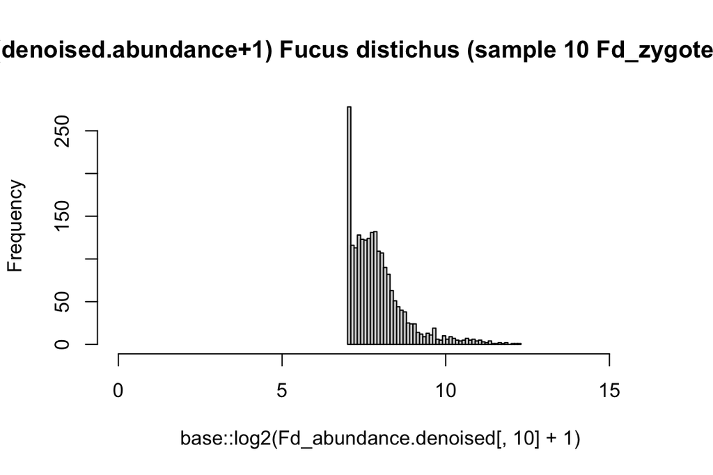

```r
graphics::hist(
  base::log2(Fd_abundance.denoised[,10]+1),
  breaks = 50,
  main = "log2(denoised.abundance+1) Fucus distichus (sample 10 Fd_zygotes_48h_1)",
  xlim = c(0,16))
```

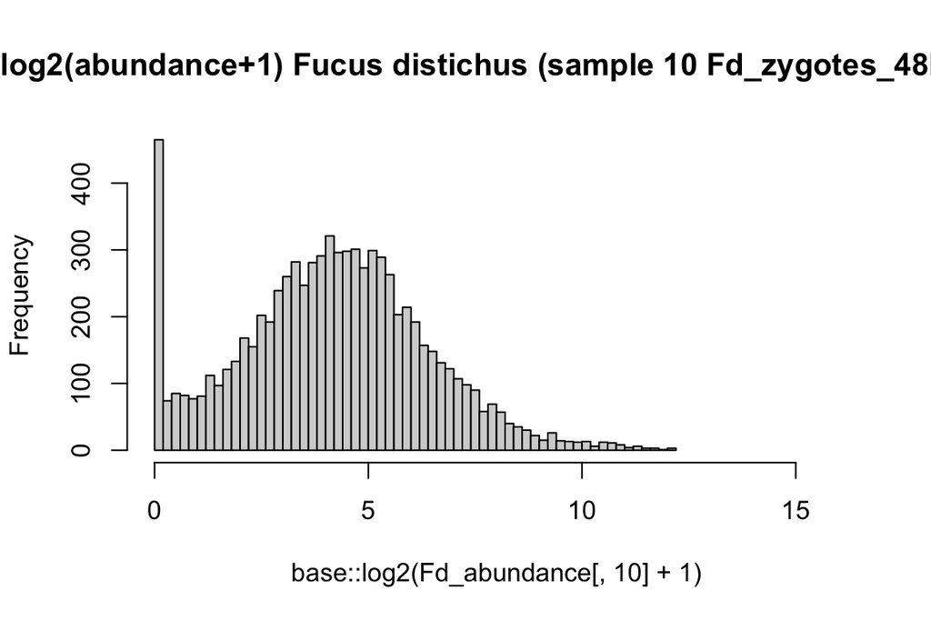

```r
graphics::hist(
  base::log2(Fd_abundance[,10]+1),
  breaks = 50,
  main = "log2(abundance+1) Fucus distichus (sample 10 Fd_zygotes_48h_1)",
  xlim = c(0,16))
```

[figure not shown]

```r
htree.denoised <- stats::hclust(dist(t(log2(Fs_abundance.denoised+1))), method = "average")
graphics::plot(htree.denoised, xlab = "hclust log2(denoised.abundance+1)", main = "Fucus serratus (denoised)")
```

[figure not shown]

```r
htree.out <- stats::hclust(dist(t(log2(Fs_abundance+1))), method = "average")
graphics::plot(htree.out, xlab = "hclust log2(abundance+1)", main = "Fucus serratus (raw)")
```

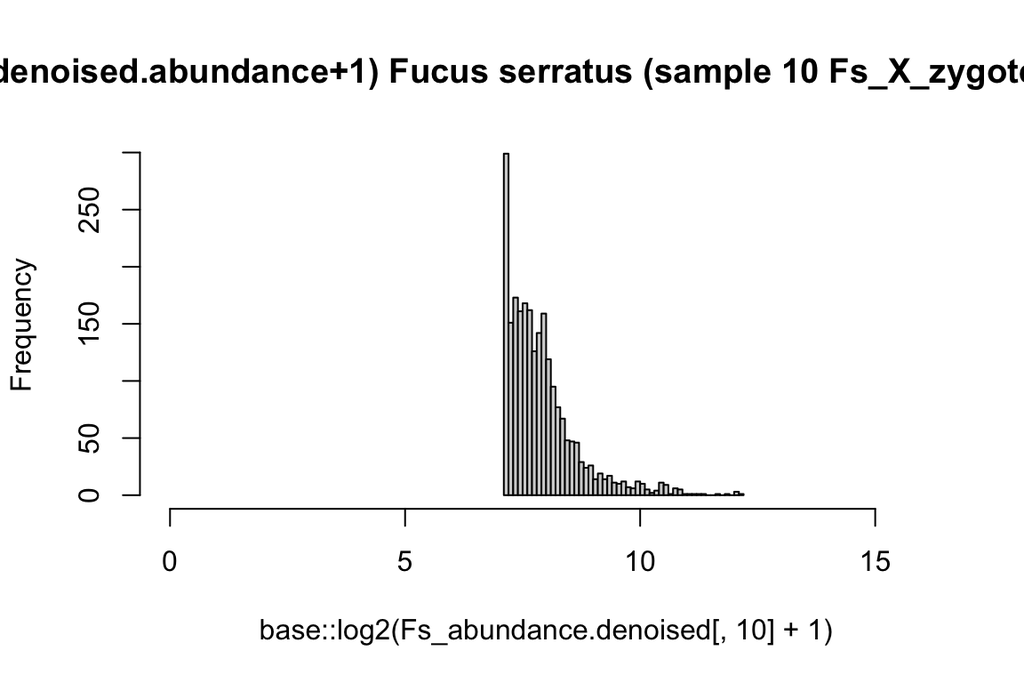

```r
graphics::hist(
  base::log2(Fs_abundance.denoised[,10]+1),
  breaks = 50,
  main = "log2(denoised.abundance+1) Fucus serratus (sample 10 Fs_X_zygotes_48h_1)",
  xlim = c(0,16))
```

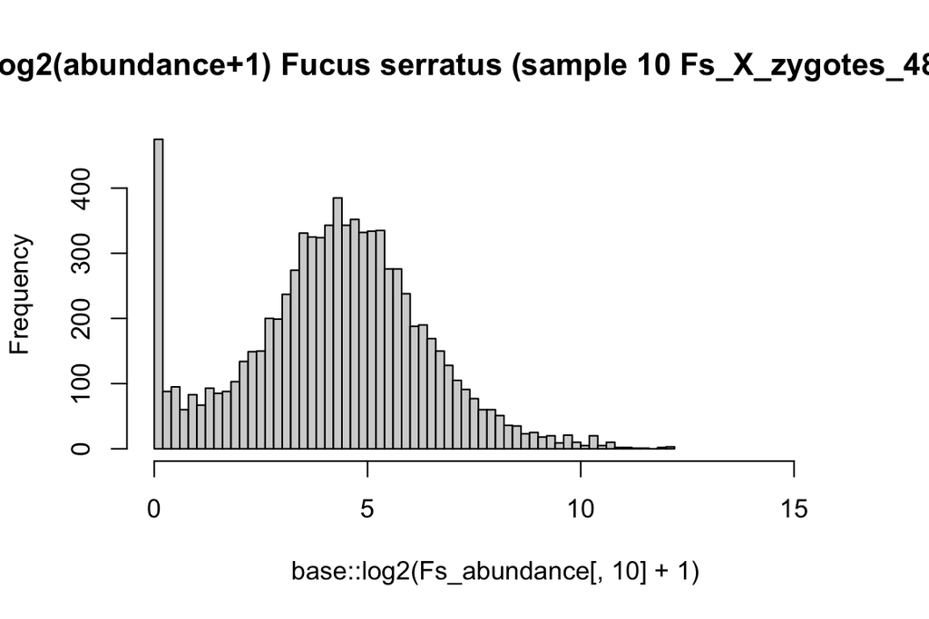

```r
graphics::hist(
  base::log2(Fs_abundance[,10]+1),
  breaks = 50,
  main = "log2(abundance+1) Fucus serratus (sample 10 Fs_X_zygotes_48h_1)",
  xlim = c(0,16))
```

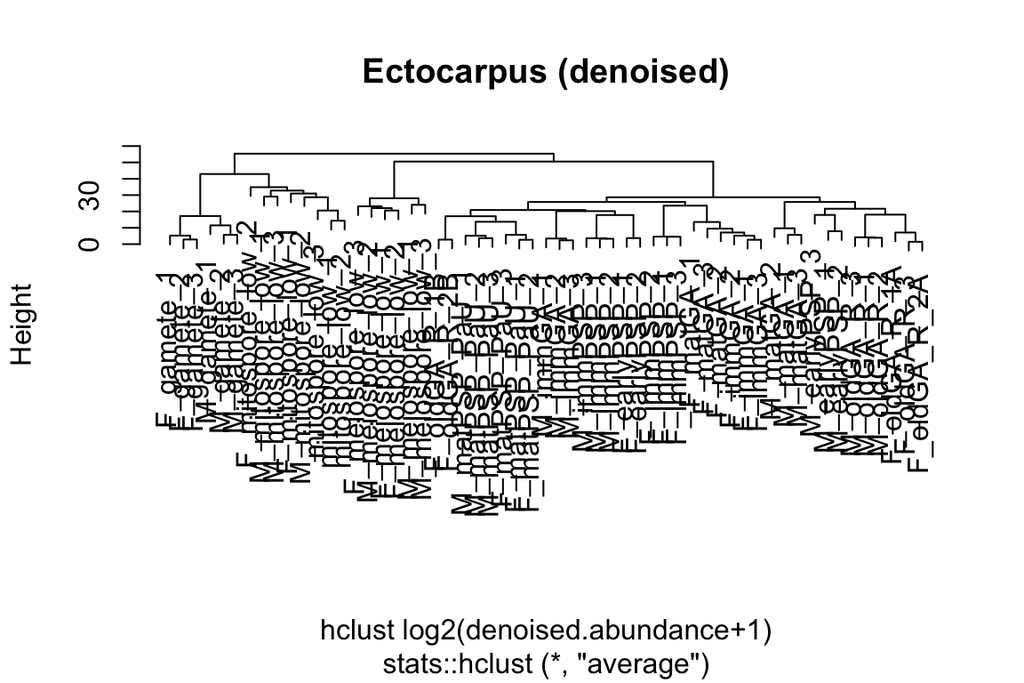

```r
htree.denoised <- stats::hclust(dist(t(log2(Ec_abundance.denoised+1))), method = "average")
graphics::plot(htree.denoised, xlab = "hclust log2(denoised.abundance+1)", main = "Ectocarpus (denoised)")
```

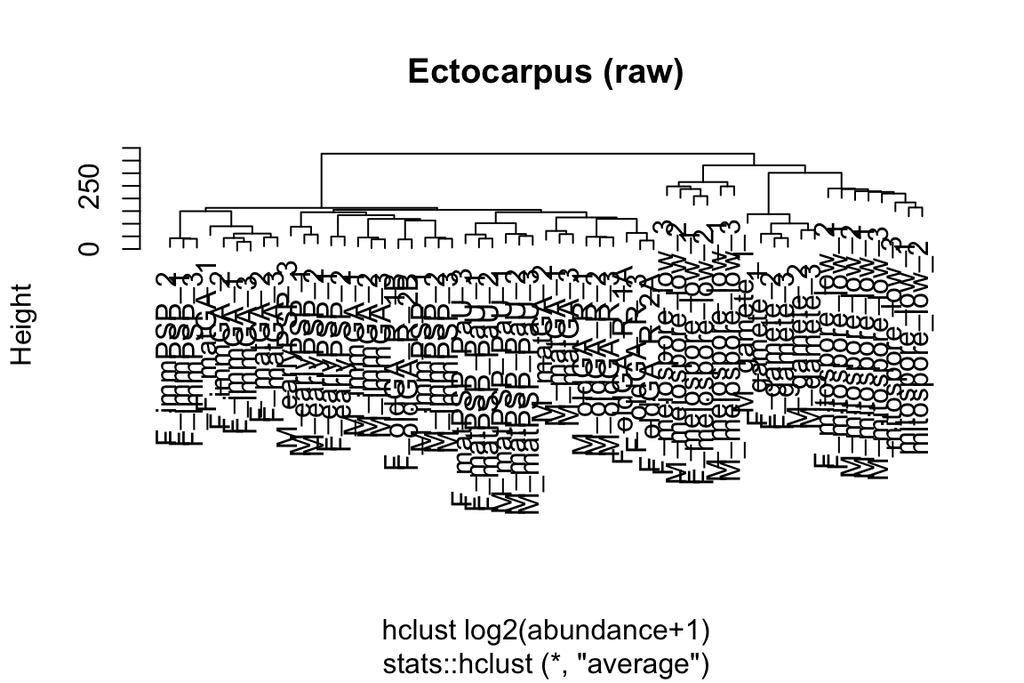

```r
htree.out <- stats::hclust(dist(t(log2(Ec_abundance+1))), method = "average")
graphics::plot(htree.out, xlab = "hclust log2(abundance+1)", main = "Ectocarpus (raw)")
```

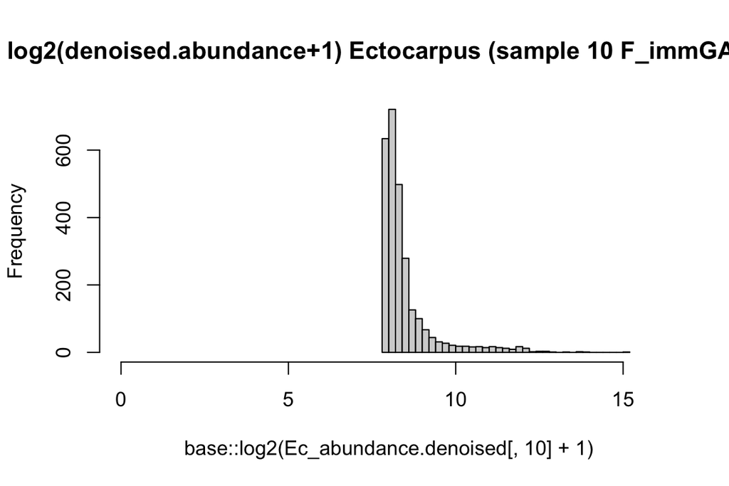

```r
graphics::hist(
  base::log2(Ec_abundance.denoised[,10]+1),
  breaks = 50,
  main = "log2(denoised.abundance+1) Ectocarpus (sample 10 F_immGA_1)",
  xlim = c(0,16))
```

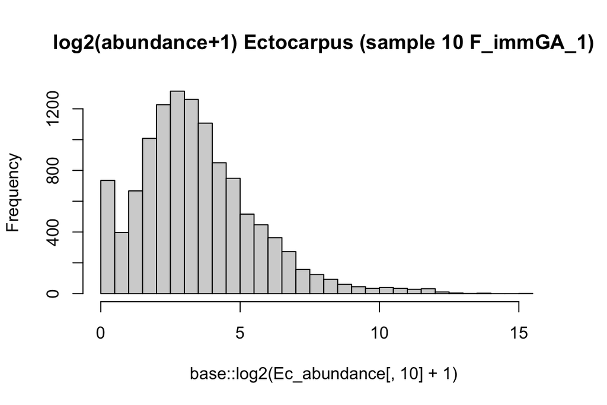

```r
graphics::hist(
  base::log2(Ec_abundance[,10]+1),
  breaks = 50,
  main = "log2(abundance+1) Ectocarpus (sample 10 F_immGA_1)",
  xlim = c(0,16))
```

With the count data (I have changed the plots to show abundance instead) the first dendogram (denoised) made more sense with the distribution of the *Fucus distichus* gametes. MatSP clustered better together and zygotes were clustered roughly based on developmental stages. There was a steep transition between 48H and 1w onwards. This was not seen with the log2(x+1) transformed raw data. Some of this improvement was seen with *Fucus serratus* and *Ectocarpus*. *However*, I now show the abundance data. The results are less clear with `hclust`, though we have to keep in mind some of its limitations. What we do know is that the *distances between the samples have gotten smaller.*

The histogram shows a lot of lower expressed genes are removed. I am unsure about the weird peaks in the *Fucus data* but I think this is because a lot of genes have 0 expression. This was seen with the gamete samples in *Ectocarpus*.

# Save count data

## Save *F. distichus* count data

Save abundance

```r
Fd_keep %>%
  dplyr::as_tibble(rownames = "GeneID") %>%
  readr::write_csv(file = "data/Fd_abundance.csv")
```

Save denoised abundance

```r
Fd_abundance.denoised %>%
  dplyr::as_tibble(rownames = "GeneID") %>%
  readr::write_csv(file = "data/Fd_abundance_denoised.csv")
```

Save counts

```r
# use counts
Fd_counts %>%
  dplyr::as_tibble(rownames = "GeneID") %>%
  readr::write_csv(file = "data/Fd_counts.csv")
```

Save denoised counts

```r
Fd_counts.denoised %>%
  dplyr::as_tibble(rownames = "GeneID") %>%
  readr::write_csv(file = "data/Fd_counts_denoised.csv")
```

Save metafile

```r
sample_info_fd %>%
  readr::write_csv(file = "data/sample_info_fd.csv")
```

## Save *F. serratus* count data

Save abundance

```r
Fs_keep %>%
  dplyr::as_tibble(rownames = "GeneID") %>%
  readr::write_csv(file = "data/Fs_abundance.csv")
```

Save denoised abundance

```r
Fs_abundance.denoised %>%
  dplyr::as_tibble(rownames = "GeneID") %>%
  readr::write_csv(file = "data/Fs_abundance_denoised.csv")
```

Save counts

```r
# use counts
Fs_counts %>%
  dplyr::as_tibble(rownames = "GeneID") %>%
  readr::write_csv(file = "data/Fs_counts.csv")
```

Save denoised counts

```r
Fs_counts.denoised %>%
  dplyr::as_tibble(rownames = "GeneID") %>%
  readr::write_csv(file = "data/Fs_counts_denoised.csv")
```

Save metafile

```r
sample_info_fs %>%
  readr::write_csv(file = "data/sample_info_fs.csv")
```

## Save *Ectocarpus* count data

Save abundance

```r
Ec_keep %>%
  dplyr::as_tibble(rownames = "GeneID") %>%
  readr::write_csv(file = "data/Ec_abundance.csv")
```

Save denoised abundance

```r
Ec_abundance.denoised %>%
  dplyr::as_tibble(rownames = "GeneID") %>%
  readr::write_csv(file = "data/Ec_abundance_denoised.csv")
```

Save counts

```r
# use counts
Ec_counts %>%
  dplyr::as_tibble(rownames = "GeneID") %>%
  readr::write_csv(file = "data/Ec_counts.csv")
```

Save denoised counts

```r
Ec_counts.denoised %>%
  dplyr::as_tibble(rownames = "GeneID") %>%
  readr::write_csv(file = "data/Ec_counts_denoised.csv")
```

Save metafile

```r
sample_info_ec %>%
  readr::write_csv(file = "data/sample_info_ec.csv")
```

## Save processed age data

```r
Ec_age %>%
  readr::write_csv(file = "data/Ec_age_processed.csv")
Fd_age %>%
  readr::write_csv(file = "data/Fd_age_processed.csv")
Fs_age %>%
  readr::write_csv(file = "data/Fs_age_processed.csv")
```